# Object Oriented Programming in Python

[figure not shown]

## **Object Oriented Programming in Python** **Instructor:** **Mehdi Rezvandehy**

Summary

Object oriented Programming (OOP) is a programming style characterized by the identification of classes of objects closely linked with the methods (functions). OOP offers the potential to evolve programming to a higher level of abstraction. It also provides flexibility for codebase through inheritance and polymorphism. This notebook presents fundamental of OOP in Python.

Python functions and data files to run this notebook are in my [Github](https://github.com/MehdiRezvandehy/Object_Oriented_Programming.git) page.

# Object-oriented Programming (OOP)

- **Procedural Programming**
  - Codes are as a separate sequence of steps
  - It is great for data analysis
  - Thinking in sequence like getting up in the morning having breakfast go to work.
  - However, OOP may not be efficient when there are many objects (go to school, play, watch TV, take plane..)
- **Object-Oriented Programming**
  - They are great to build frameworks and tools
  - To make a maintainable and reusable codes
  - Code are considered as interactions of objects
- **Objects as data structures**
  - `Object` = `state` such as **phone**, **email**.. of customers (called attributes too) + `behavior` such as **place of order**, **cancel order**... of customers (called methods too)
  - **Encapsulation:** bundling data with code operating on it

**Classes are blueprints for objects that are outlining possible states and behaviors**

- **Objects in Python**
  - Everything in Python is an object
  - Every object has a class
  - we can use type() to find the class of object

See illustrations below for classes and objects for car:

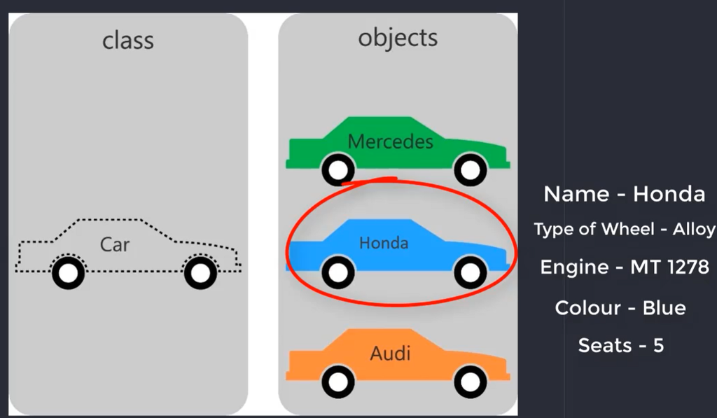

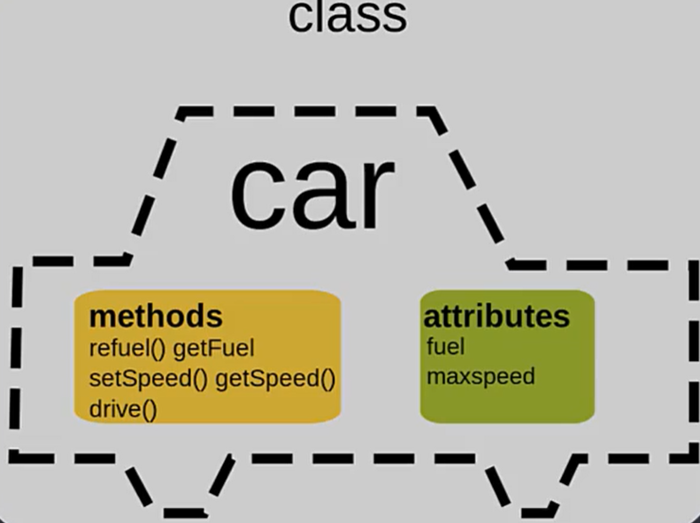

```python
import numpy as np
a = np.array([4,7,9,5])
print(type(a))
```

```
<class 'numpy.ndarray'>
```

```python
print(f"the class of for {10} is {type(10)}")
print(f"the class of for Hello is {type('Hello')}")
print(f"the class of for {np.mean} is {type(np.mean)}")
```

```
the class of for 10 is <class 'int'>
the class of for Hello is <class 'str'>
the class of for <function mean at 0x0000022CC085B430> is <class 'function'>
```

- **Attributes and Methods**
  - State <=> attributes
  - Behavior <=> methods
  - We can use obj. to access attributes and methods

```python
# shape attribute
a = np.array([5,1,0,4])
a.shape
```

```
(4,)
```

```python
# reshape method
a = np.array([5,1,0,4])
a.reshape(2,2)
```

```
array([[5, 1],
       [0, 4]])
```

Now we can rephrase object as **Object = attributes + methods**:

- attributes <=> **variables**
- methods <=> **function()**

```python
# reshape method
a = np.array([5,1,0,4])
# we can list all attributes and methods
dir(a)
```

[output not shown]

[output cut: 107 more lines]

```
 'sort',
 'squeeze',
 'std',
 'strides',
 'sum',
 'swapaxes',
 'take',
 'tobytes',
 'tofile',
 'tolist',
 'tostring',
 'trace',
 'transpose',
 'var',
 'view']
```

# Type hints

Type hinting is a formal solution to statically indicate the type of a value within your Python code. It was introduced in **Python 3.5**. Here’s an example of adding type information to a function. You annotate the arguments and the return value:

Here is an example to represent how to convert one type to another.

```python
a_string_variable = "Hello, world!"
print(type(a_string_variable))
```

```
<class 'str'>
```

```python
a_string_variable = 42
print(type(a_string_variable))
print(id(a_string_variable))
print(hash(a_string_variable))
```

```
<class 'int'>
2390776311376
42
```

Here are the two steps, shown side by side, showing how the variable is moved from object to object:

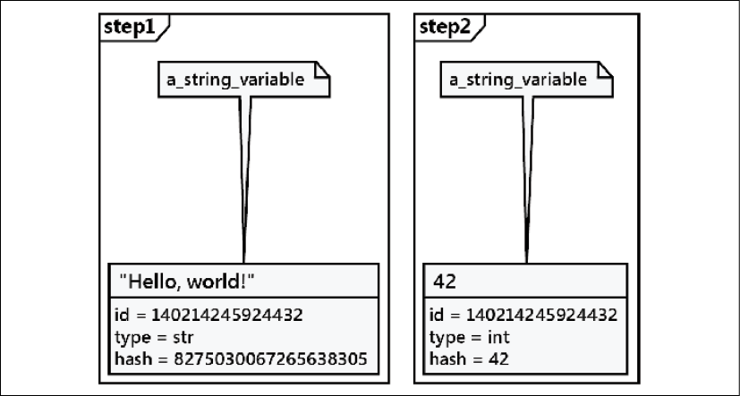

**The various properties are part of the object, not the variable.** When we check the type of a variable with `type()`, we see the type of the object the variable currently references. The variable doesn't have a type of its own; it's nothing more than a name. Similarly, asking for the `id()` of a variable shows the ID of the object the variable refers to. So obviously, the name a_string_variable is a bit misleading if we assign the name to an integer object.

Here is an example of type hints in Python:

```python
def say_greet(name: str) -> str:
    return "Hello, " + name
```

Here is another example:

```python
def headline(text: str, align: bool = True) -> str:
    if align:
        return f"{text.title()}\n{'-' * len(text)}"
    else:
        return f" {text.title()} ".center(50, "o")
```

```python
print(headline("check python type ", align=False))
```

```
ooooooooooooooo Check Python Type  ooooooooooooooo
```

```python
text='my name is mehdi'
```

- Use normal rules for colons, that is, **no space before and one space after a colon (text: str).**
- Use spaces **around the = sign** when combining an argument annotation with a default value (**align: bool = True**).
- Use spaces **around the -> arrow** (**def headline(...) -> str**).

Another example is below:

```python
def main(val) -> None:
    print(odd(val))

def odd(n: int) -> bool:
    return n % 2 != 0

if __name__ == "__main__":
    main(11)
```

```
True
```

The `main()` function doesn't have a return type; `mypy` suggests including **-> None** to make the **absence of a return value perfectly explicit.**

# Introduction for Classes in Python

- Class definition in Python can be started as `class <name>:`
- The code inside the `class` should be indented
- Empty class can be created by using `pass`

```python
class CustInfo:
    pass
```

- to create an object `class name+()` should be used

```python
cus1 = CustInfo()
cus2 = CustInfo()
```

cus1 and cus2 are objects

```python
a = CustInfo()
print(a)
b = CustInfo()
print(b)
```

```
<__main__.CustInfo object at 0x0000022CC1B5EDC0>
<__main__.CustInfo object at 0x0000022CC1B5EF10>
```

This code instantiates two objects from the new class, assigning the object variable names `a` and `b`. Creating an instance of a class is a matter of typing the class name, followed by a pair of parentheses. It looks much like a function call; `calling a class will create a new object`. When printed, the two objects tell us which class they are and what memory address they live at. Memory addresses aren't used much in Python code.

```python
a is b
```

```
False
```

## How to Add Method to a Class

- The method is the function within class
- `self` should be applied as first argument for method definition
- `self` should be ignored when calling method on an object

```python
class CustInfo:
    def idtfy(self, name):
        print("I am Customer " + name)
```

```python
cust_name = CustInfo()
cust_name.idtfy("Mehdi")
```

```
I am Customer Mehdi
```

- In class definition, `self` is a substitute for a particular object

The one difference, syntactically, between methods of classes and functions outside classes is that methods have one required argument. This argument is conventionally named `self`; I've never seen a Python programmer use any other name for this variable (convention is a very powerful thing). There's nothing technically stopping you, however, from calling it this or even Martha, but it's best to acknowledge the social pressure of the Python community codified in PEP 8 and stick with `self`.

**Pay attention to the difference between a class and an object in this discussion. We can think of the method as a function attached to a class. `The self parameter refers to a specific instance of the class.` When you call the method on two different objects, you are calling the same method twice, but passing two different objects as the self parameter.**

What happens if we forget to include the self argument in our class definition? Python will bail with an error message, as follows:

```python
class Point:
    def reset():
        pass

p = Point()
p.reset()
```

```
---------------------------------------------------------------------------
TypeError                                 Traceback (most recent call last)
~\AppData\Local\Temp\ipykernel_18944\1841119531.py in <module>
      4
      5 p = Point()
----> 6 p.reset()

TypeError: reset() takes 0 positional arguments but 1 was given
```

## How to Add Attribute to a Class

```python
class CustInfo:
    # set the name attribute of an object as name
    def name_assign(self, name):
        # Create an attribute by assigning a value
        self.name = name   # When set_name is called, .name will created
```

```python
cust = CustInfo()                     # Name does not exist yet
cust.name_assign("Mehdi Rezvandehy")  # Create a name and assign to Mehdi Rezvandehy
print(cust.name)
```

```
Mehdi Rezvandehy
```

```python
class CustInfo:
    def name_assign(self, name):
        self.name = name

    # Using .name from the object it*self*
    def idtfy(self):
        print("I am Customer " + self.name)
```

```python
cust = CustInfo()
cust.name_assign("Mehdi Rezvandehy")
cust.idtfy()
```

```
I am Customer Mehdi Rezvandehy
```

```python
# We can also use __init__ as below for creating attributes
class CustInfo:
    def __init__(self, name):
        self.name = name
    def idtfy(self):
        print("I am Customer " + self.name)
```

```python
cust = CustInfo("Mehdi Rezvandehy")
cust.idtfy()
```

```
I am Customer Mehdi Rezvandehy
```

How do we `pass multiple arguments to a method?` Let's add a new method that allows us to move a point to an arbitrary position, not just to the origin. We can also include a method that accepts another Point object as input and returns the distance between them:

```python
import math
class Point:
    def move(self, x: float, y: float) -> None:
        self.x = x
        self.y = y
    def reset(self) -> None:
        self.move(0, 0)
    def calculate_distance(self, other: "Point") -> float:
        return math.hypot(self.x - other.x, self.y - other.y)
```

We've defined a class with two attributes, `x`, and `y`, and three separate methods, `move()`, `reset()`, and `calculate_distance()`.

The `move()` method accepts two arguments, `x` and `y`, and sets the values on the `self` object. The `reset()` method calls the `move()` method, since a reset is just a move to a specific known location.

The `calculate_distance()` method computes the Euclidean distance between two points. Here's an example of using this class definition. This shows how to call a method with arguments: include the arguments inside the parentheses and use the same dot notation to access the method name within the instance. We just picked some random positions to test the methods. The test code calls each method and prints the results on the console:

```python
set1 = Point()
set2 = Point()
set1.reset()
set2.move(9, 0)
print(set2.calculate_distance(set1))

assert set2.calculate_distance(set1) == set1.calculate_distance(
   set2)
```

```
9.0
```

The `assert` statement is a marvelous test tool; the program will bail if the expression after assert evaluates to False (or zero, empty, or None). In this case, we use it to ensure that the distance is the same.

## "**init**" Constructor

- Within a class, methods are function
- `self` as the first argument, we can use other keys but it is not recommended.
- Attributes are defined by the assignment
- Attributes in class can be referred via `self.---`

We can add data to object when we created it by **constructor** `__init__()`, which is called every time an object is created.

```python
class CustInfo:
    def __init__(self, name, balance=100): # set defalt value for balance as $100
        self.name = name
        self.balance = balance
        print("The __init__ method was called")

cust = CustInfo("Mehdi Rezvandehy",20) #<--- __init__ is implicitly called
print(cust.name)
print(cust.balance)
```

```
The __init__ method was called
Mehdi Rezvandehy
20
```

Reading attributes in the constructor are:

- We can easier know all the attributes
- When the object is created, attributes are also created
- It makes your code more usable and maintainable

Best practice when dealing with classes

- Attributes should be initialized in `__init__()`
- Naming for classes can have both lower and upper case e.g. `UseCase`. We do not normally have `_` for classes; however, function and attribute should always have lower case `kernel_density_estimate`
- Although `self` can be replaced with any word, it should be kept as `self`
- It is always recommended to use docstrings for class:

### Type Hints

Type hinting is a formal solution to statically indicate the type of a value within your Python code. It was introduced in **Python 3.5**. Here’s an example of adding type information to a function. You annotate the arguments and the return value:

Hints are optional. They don't do anything at runtime. There are tools, however, **that can examine the hints to check for consistency.** If we don't want to make the two arguments required, we can use the same syntax Python functions use to **provide default arguments.** The keyword argument syntax appends **an equals sign after each variable name.** If the calling object does not provide this argument, then the default argument is used instead. The variables will still be available to the function, but they will have the values specified in the argument list. Here's an example:

Here is an example to represent how to convert one type to another.

```python
a_string_variable = "Hello, world!"
print(type(a_string_variable))
```

```
<class 'str'>
```

```python
a_string_variable = 42
print(type(a_string_variable))
print(id(a_string_variable))
print(hash(a_string_variable))
```

```
<class 'int'>
2390776311376
42
```

Here are the two steps, shown side by side, showing how the variable is moved from object to object:

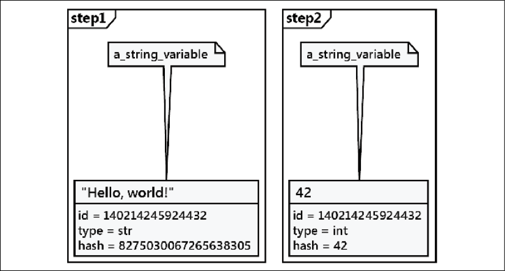

**The various properties are part of the object, not the variable.** When we check the type of a variable with `type()`, we see the type of the object the variable currently references. The variable doesn't have a type of its own; it's nothing more than a name. Similarly, asking for the `id()` of a variable shows the ID of the object the variable refers to. So obviously, the name a_string_variable is a bit misleading if we assign the name to an integer object.

Here is an example of type hints in Python:

```python
def say_greet(name: str) -> str:
    return "Hello, " + name
```

Here is another example:

```python
def headline(text: str, align: bool = True) -> str:
    if align:
        return f"{text.title()}\n{'-' * len(text)}"
    else:
        return f" {text.title()} ".center(50, "o")
```

```python
print(headline("check python type ", align=False))
```

```
ooooooooooooooo Check Python Type  ooooooooooooooo
```

```python
text='my name is mehdi'
```

- Use normal rules for colons, that is, **no space before and one space after a colon (text: str).**
- Use spaces **around the = sign** when combining an argument annotation with a default value (**align: bool = True**).
- Use spaces **around the -> arrow** (**def headline(...) -> str**).

Another example is below:

```python
def main(val) -> None:
    print(odd(val))

def odd(n: int) -> bool:
    return n % 2 != 0

if __name__ == "__main__":
    main(11)
```

```
True
```

Type hints within Python class:

```python
class Point:
    def __init__(self, x: float = 0, y: float = 0) -> None:
        self.move(x, y)
```